# Learn History from 2010 China Population

The latest census in China was taken in 2010. The data are available online from [National Bureau of Statistics of the China](http://www.stats.gov.cn/tjsj/pcsj/rkpc/6rp/indexch.htm). Although this five-year-old census maybe too acient to be used for looking into the future of the fast changing China, it is actually a reliable source to look back into China’s history, especially when more detailed historical data are not accessible.

In this post we will look at population data. The following figure plots the number of people against the year of birth. Note that the numbers are of those who were still alive in 2010, not the total number of people born in that year. Actually there is no way to know the number of birth prior to 1949, when China was constantly at wars.

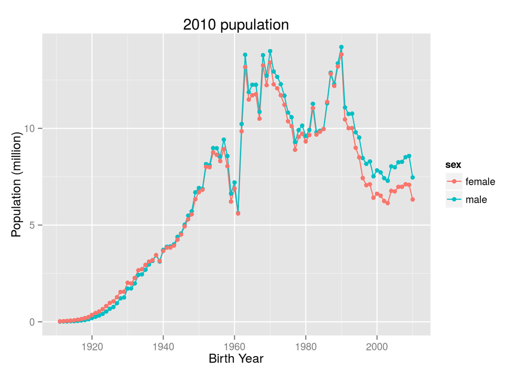

The most striking feature in this figure is that the population change over birth year is so violent. Normally, we would expect a smooth change over birth age, with fewer at older ages and more at younger ages, as a result of natural death and natural poplation growth.

The violent changes in population indicates dramatical events. The first events occured around 1960, where there is a sudden drop in population. This event is officially called three-year natural disaster , or three-year difficult period, by the government, or called three-year great famine by many. There are still fier??ce debate over how many people were starved to death as official numbers are not available, this plot clearly shows that up to 40% fewer people survived to 2010 born in those years. This could be due to much fewer baby were born or the infant fatality is way too high. The population recovered quickly in 1962, overshot in 1963, and back to normal trend until 1970.

So what happend after 1970?